# Lake Water Quality Analysis

Amanda Hastings

2022-02-24

# LAGOS Analysis

## Loading in data

### First download and then specifically grab the locus (or site lat longs)

```r
#Lagos download script
#lagosne_get(dest_folder = LAGOSNE:::lagos_path(),overwrite=T)

#Load in lagos
lagos <- lagosne_load()
#Grab the lake centroid info
lake_centers <- lagos$locus

# Make an sf object
spatial_lakes <- st_as_sf(lake_centers,coords=c('nhd_long','nhd_lat'),
                          crs=4326)

#Grab the water quality data
nutr <- lagos$epi_nutr

#Look at column names
#names(nutr)
```

### Subset columns nutr to only keep key info that we want

```r
clarity_only <- nutr %>%
  select(lagoslakeid,sampledate,chla,doc,secchi) %>%
  mutate(sampledate = as.character(sampledate) %>% ymd(.))
```

### Keep sites with at least 200 observations

```r
#Look at the number of rows of dataset
#nrow(clarity_only)

chla_secchi <- clarity_only %>%
  filter(!is.na(chla),
         !is.na(secchi))

# How many observations did we lose?
# nrow(clarity_only) - nrow(chla_secchi)


# Keep only the lakes with at least 200 observations of secchi and chla
chla_secchi_200 <- chla_secchi %>%
  group_by(lagoslakeid) %>%
  mutate(count = n()) %>%
  filter(count > 200)
```

### Join water quality data to spatial data

```r
spatial_200 <- inner_join(spatial_lakes,chla_secchi_200 %>%
                            distinct(lagoslakeid,.keep_all=T),
                          by='lagoslakeid')
```

### Mean Chl_a map

```r
### Take the mean chl_a and secchi by lake

mean_values_200 <- chla_secchi_200 %>%
  # Take summary by lake id
  group_by(lagoslakeid) %>%
  # take mean chl_a per lake id
  summarize(mean_chl = mean(chla,na.rm=T),
            mean_secchi=mean(secchi,na.rm=T)) %>%
  #Get rid of NAs
  filter(!is.na(mean_chl),
         !is.na(mean_secchi)) %>%
  # Take the log base 10 of the mean_chl
  mutate(log10_mean_chl = log10(mean_chl))

#Join datasets
mean_spatial <- inner_join(spatial_lakes,mean_values_200,
                          by='lagoslakeid')

#Make a map
mapview(mean_spatial,zcol='log10_mean_chl')
```

[interactive chart not shown]

# Class work

## 1) What is the correlation between Secchi Disk Depth and Chlorophyll a for

sites with at least 200 observations?

- Here, I just want a plot of chla vs secchi for all sites

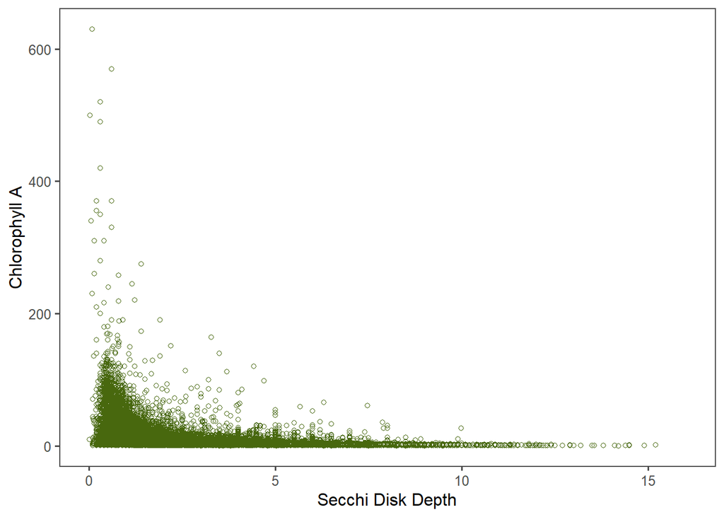

```r
#Plot secchi disk depth by cholorphyll a
library(ggthemes)
ggplot(chla_secchi_200, aes(x = secchi, y = chla)) +
  geom_point(shape = 1, color="#48680E")+
  theme_few()+
  labs(y="Chlorophyll A", x="Secchi Disk Depth")+
  xlim(0,16)
```

There is a negative correlation between secchi disk depth and chlorophyll a levels, where shallower secchi disk depths are associated with higher chlorophyll a levels.

## Why might this be the case?

High cholorphyll a concentrations are associated with high density(s) of photosynthetic organisms, such as algae. Meanwhile, secchi disks are used to assess water turbidity, where the depth of disk disappearance indicates the transparency of the water (Fuller and Minnerick 2007). Where algae abundance is high, the depth where light can penetrate a water body diminishes; thus, secchi disk depth decreases (Fuller and Minnerick 2007).

Fuller, LM & Minnerick, RJ (2007). Predicting Water Quality by Relating Secchi-Disk Transparency and Chlorophyll a Measurements to Landsat Satellite Imagery for Michigan Inland Lakes, 2001–2006. USGS, August 2007, 1–4. [http://pubs.usgs.gov/fs/2007/3022/pdf/FS2007-3022.pdf]

## 2) What states have the most data?

### 2a) First you will need to make a lagos spatial dataset that has the total

number of counts per site.

```r
#Create lagos spatial dataset with total number of counts per site

site_counts <- chla_secchi %>%
  group_by(lagoslakeid) %>%
  mutate(count = n())

#Add geographic information to site counts data

geo_counts <- inner_join(site_counts,lake_centers, by= 'lagoslakeid')%>%
  select(lagoslakeid,nhd_long,nhd_lat, count, secchi, chla)

#Create spatial object for lagos dataset

spatial_counts <- st_as_sf(geo_counts,coords=c('nhd_long','nhd_lat'),
                          crs=4326)
```

### 2b) Second, you will need to join this point dataset to the us_boundaries data.

```r
#Use a spatial join to combine point dataset and us_boundaries data

#Parse out state boundaries from us_boundaries data

states <- us_states()

#Use spatial join to overlay point dataset (original lagos spatial dataset) and state boundaries

overlay <- st_join(spatial_counts,states)
```

### 2c) Then you will want to group by state and sum all the observations in

that state and arrange that data from most to least total observations per state.

```r
# Group by state and sum number of observations by state

summed_overlay <- overlay %>%
  group_by(state_name) %>%
  summarize(sum_count = sum(count)) %>%
  arrange(desc(sum_count))

#Print first six rows of dataframe

head(summed_overlay)
```

```
## Simple feature collection with 6 features and 2 fields
## Geometry type: MULTIPOINT
## Dimension:     XY
## Bounding box:  xmin: -96.7326 ymin: 36.56094 xmax: -71.13 ymax: 49.07966
## Geodetic CRS:  WGS 84
## # A tibble: 6 x 3
##   state_name   sum_count                                                geometry
##   <chr>            <int>                                        <MULTIPOINT [°]>
## 1 Minnesota      6397053 ((-91.7611 48.07994), (-91.79656 48.07795), (-92.78202~
## 2 Vermont        2800140 ((-71.69262 44.49016), (-71.65014 44.6488), (-71.64064~
## 3 New York       2434082 ((-73.85454 44.48571), (-73.78217 44.46384), (-73.5003~
## 4 Wisconsin      2045199 ((-87.15812 45.03619), (-87.87378 45.70961), (-87.8165~
## 5 Rhode Island   1989837 ((-71.58223 41.98801), (-71.76816 42.00814), (-71.7923~
## 6 Missouri       1372894 ((-95.58194 40.47874), (-95.13708 40.35073), (-94.9173~
```

The top five states with the most data include: Minnesota, Vermont, New York, Wisconsin, and Rhode Island.

##3 Is there a spatial pattern in Secchi disk depth for lakes with at least 200 observations?

```r
#Filter by 200 or more observations
#Calculate the mean secchi depth by lake

secchi200 <- chla_secchi %>%
  group_by(lagoslakeid) %>%
  mutate(count = n()) %>%
  filter(count > 200) %>%
  summarize(mean_secchi = mean(secchi))

#Add geographic information, joining by lagoslakeid

secchi200_locus <- inner_join(secchi200, lake_centers, by='lagoslakeid') %>%
  select(lagoslakeid, nhd_long, nhd_lat, mean_secchi)

#Create a spatial object with lagoslakeid and mean secchi data

spatial_secchi200 <- st_as_sf(secchi200_locus,coords=c('nhd_long','nhd_lat'),
                          crs=4326)

#Visualize secchi data within interactive plot/map

mapview(spatial_secchi200, zcol='mean_secchi', layer.name='Secchi Disk Depth', canvas=TRUE)
```

[interactive chart not shown]

I do not see an exceptionally strong spatial pattern in secchi disk depth in lakes with at least 200 observations, given the number of observations above 200 is small. However, the patch of lakes near/surrounding the Minneapolis-Saint Paul sprawl in Minnesota have broadly shallower secchi disk depths. Meanwhile, lakes in more remote areas in northern Wisconsin and near the Adirondacks in New York have broadly deeper secchi disk depths. It could be a stretch, but sufficient to say that lakes within more remote areas have generally deeper secchi depths and urban areas shallower depths.